# Lab 05: Introduction to `ggplot2`

### Building Plots Layer by Layer

The power of ggplot2 lies in its ability to add layers to a plot. Let’s add a smooth line to our scatter plot.

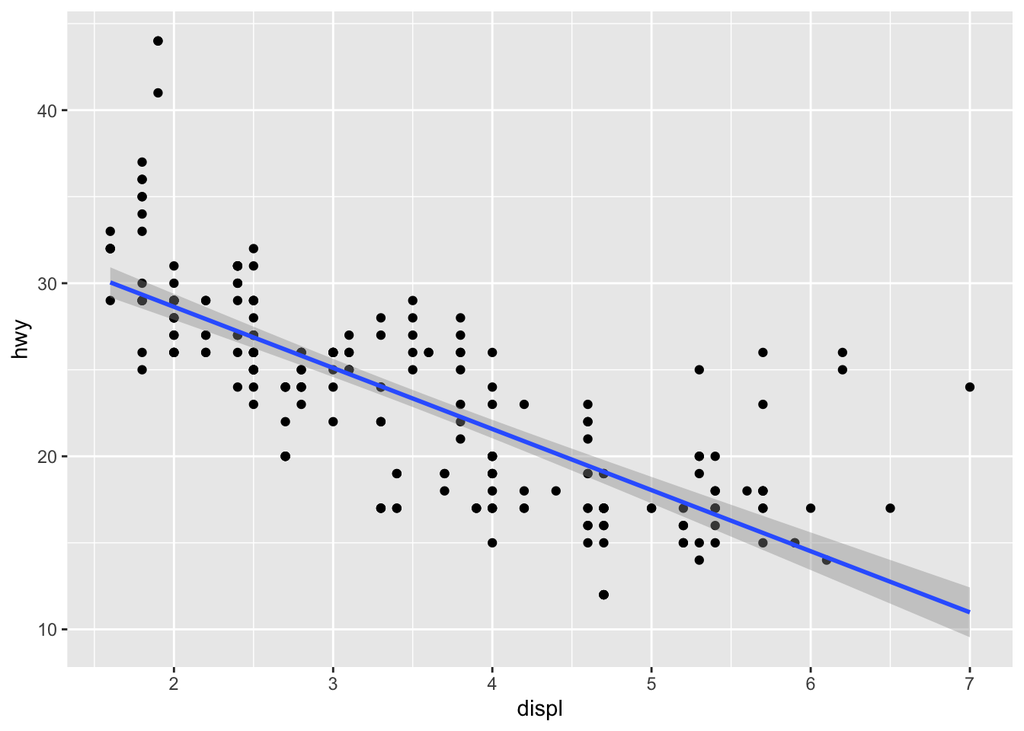

```r
ggplot(data = mpg) +
  geom_point(mapping = aes(x = displ, y = hwy)) +
  geom_smooth(mapping = aes(x = displ, y = hwy), method = "lm")
```

### Facets for Conditional Plots

To explore the data further, you might create plots for subsets of the data. This is where facets come in handy.

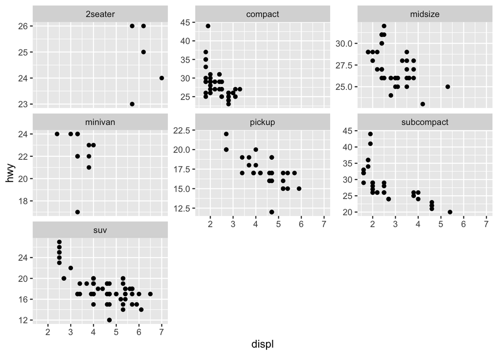

```r
ggplot(data = mpg) +
  geom_point(mapping = aes(x = displ, y = hwy)) +
  facet_wrap(~class, scales = "free_y")
```

### Themes

The theme of a `ggplot2` plot controls the non-data ink on a graphic, influencing display properties such as font types, sizes, colors, and the plot background. While the defaults in ggplot2 are chosen to be aesthetically pleasant, you might need to adjust these settings for better communication or stylistic preferences, which is where custom theming comes into play.

### Customizing with ggthemes

For those who wish to apply different stylistic themes to their `ggplot2` plots, the `ggthemes` package offers a variety of options. The `ggthemes` package extends the capabilities of `ggplot2` by providing additional themes and scales that mimic the styles found in other software, among various publications, and even from the work of renowned experts in data visualization, like Edward Tufte.

Here is how to install and use `ggthemes`:

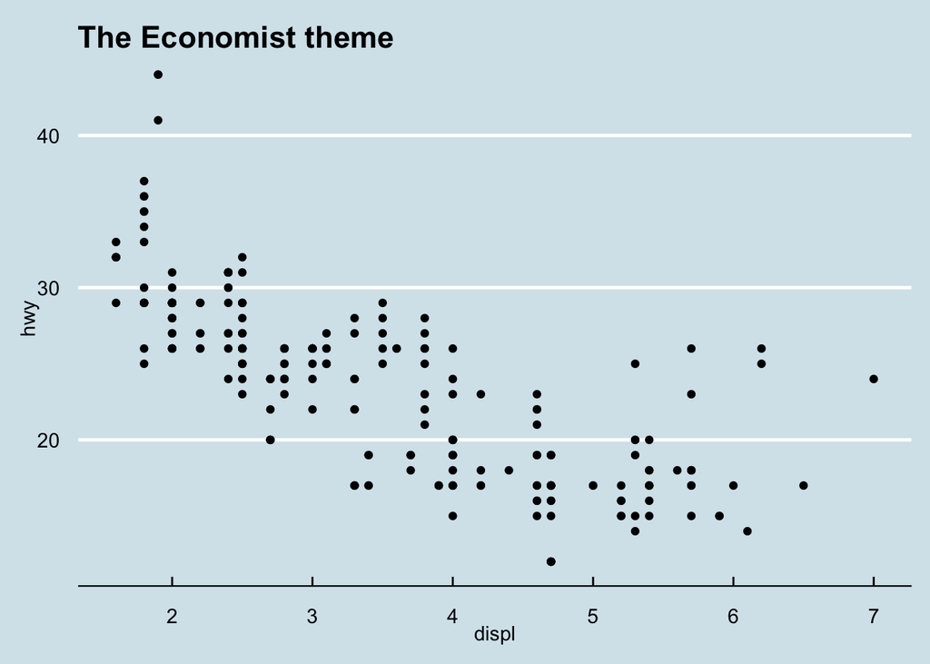

```r
# install.packages("ggthemes")
library(ggthemes) # Load the ggthemes package

# Create a ggplot and apply a theme from ggthemes
ggplot(data = mpg) +
  geom_point(mapping = aes(x = displ, y = hwy)) +
  labs(
    title = "The Economist theme"
  ) +
  theme_economist()
```

By using `ggthemes`, you can quickly give your plots a professional and polished look without the need for extensive customization. The package allows you to experiment with various established graphical styles and find the one that best suits the story your data is telling.

### Aesthetic grouping

In `ggplot2`, grouping allows you to differentiate between subsets of data based on some categorical variables. With the `mtcars` dataset, we can group data based on variables such as the number of cylinders (`cyl`) or the transmission type (`am`).

Let’s create a line plot showing the relationship between the weight (`wt`) and miles per gallon (`mpg`), grouped by the number of cylinders (`cyl`).

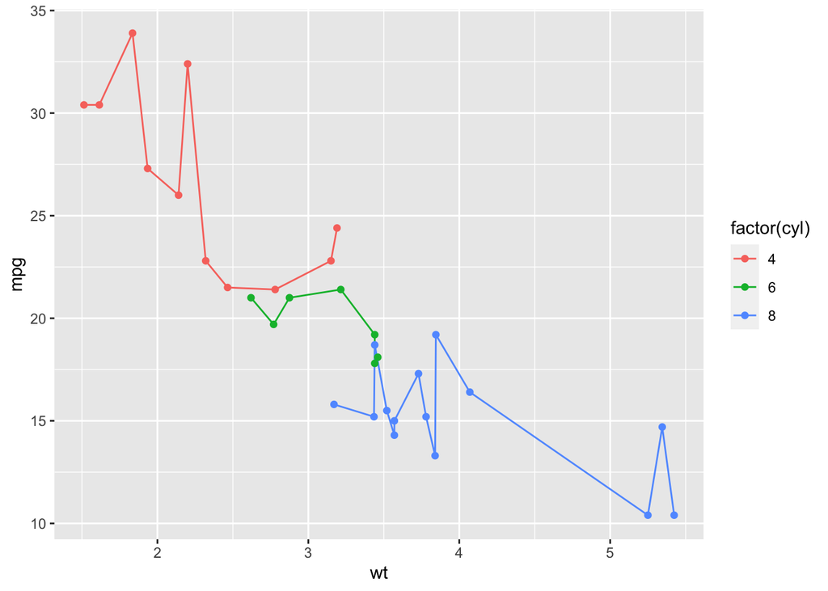

```r
# Base plot
ggplot(mtcars, aes(x = wt, y = mpg, group = factor(cyl), color = factor(cyl))) +
  geom_line() +
  geom_point() # Add points for clarity
```

Here, the `factor(cyl)` function is used to ensure that `cyl` is treated as a categorical variable. The `group` and `color` aesthetics are set to `factor(cyl)`, which instructs `ggplot2` to draw different lines for cars with different numbers of cylinders, each in a different color. Grouping in `ggplot2` provides a way to visually distinguish between different subsets of data, either by drawing different elements for each group or by using different colors or fills. By using the `mtcars` dataset, we can easily explore these concepts with real data.

## Further Reading

For those interested in learning more about `ggplot2`, the following resources are highly recommended:

- [“ggplot2: Elegant Graphics for Data Analysis”](https://ggplot2-book.org/) by Hadley Wickham.
- The [R for Data Science](https://r4ds.had.co.nz/data-visualisation.html) online chapters on data visualisation.
- The extensive documentation and examples on the [ggplot2 website](https://ggplot2.tidyverse.org/reference/).

# Two-Stage Least Squares (2SLS)

Two-Stage Least Squares (2SLS) is an estimation technique used when dealing with endogenous regressors in a regression model. An endogenous regressor is one that is correlated with the error term in the model, which violates the ordinary least squares (OLS) assumption of exogeneity. This correlation can lead to biased and inconsistent OLS estimates.

2SLS is a form of instrumental variable (IV) estimation where the potentially problematic endogenous variable is replaced by a variable that is correlated with the endogenous regressor but uncorrelated with the error term, called an instrument.

### Steps in 2SLS

1. **First Stage**: Regress the endogenous variable on the instrument(s) to obtain predicted values.
2. **Second Stage**: Use these predicted values as an explanatory variable in the regression model instead of the actual endogenous variable.

### Implementing 2SLS in R

Below are the steps for conducting a 2SLS regression in R and visualizing the results with `ggplot2`.

```r
# Assuming 'data' is your dataframe with variables Y, X, and Z
first_stage <- lm(X ~ Z, data = data)
data$X_hat <- predict(first_stage, data)
```

```r
second_stage <- lm(Y ~ X_hat, data = data)
summary(second_stage) # Output the summary of the regression
```

### Ex. 2SLS. Card dataset

The `Card` dataset provides an excellent opportunity to demonstrate the Two-Stage Least Squares (2SLS) method. This econometric technique is particularly useful when dealing with endogeneity in regression models. In the context of this dataset, we aim to estimate the causal effect of education (`educ`) on log wages (`lwage`), while acknowledging that education is potentially endogenous.

The `Card` dataset originates from a study by economist David Card which investigates the return to education. It includes the following key variables:

- `educ`: The individual’s years of education.
- `nearc4`: A binary indicator for proximity to a 4-year college.
- `lwage`: The natural logarithm of the individual’s wage.

The dataset can be downloaded via the `woolridge` package:

```r
# Load package
pacman::p_load("wooldridge")

# Load the data
data("card", package = "wooldridge")

# Print first 6 rows
card %>% select(educ, nearc4, lwage) %>% head()
```

```
  educ nearc4    lwage
1    7      0 6.306275
2   12      0 6.175867
3   12      0 6.580639
4   11      1 5.521461
5   12      1 6.591674
6   12      1 6.214608
```

### The 2SLS Estimation Procedure

The 2SLS estimation can be described in two stages:

First Stage: Predicting the Endogenous Variable

In the first stage, we regress the endogenous variable, `educ`, on the instrumental variable `nearc4` (and other exogenous covariates if necessary). The goal is to obtain the predicted values of `educ`, which are uncorrelated with the error term in the wage equation.

```r
# First Stage Regression
first_stage <- lm(educ ~ nearc4, data = card)
predicted_educ <- predict(first_stage)
```

Second Stage: Regressing the Dependent Variable on the Predicted Values

In the second stage, we use the predicted values of education obtained from the first stage to estimate its effect on log wages.

```r
# Second Stage Regression
second_stage <- lm(lwage ~ predicted_educ, data = card)
broom::tidy(second_stage)
```

```
# A tibble: 2 × 5
  term           estimate std.error statistic  p.value
  <chr>             <dbl>     <dbl>     <dbl>    <dbl>
1 (Intercept)       3.77     0.274      13.7  1.13e-41
2 predicted_educ    0.188    0.0207      9.10 1.65e-19
```

The coefficient of `predicted_educ` in the second stage regression represents the estimated causal effect of education on log wages, controlling for potential endogeneity.